# The report for differential binding analysis comparing A_vs_B

This automated report was generated by C3G GenPipes pipeline on

2022-07-17

# DiffBind Analysis

#### Using DBA_DESEQ2 as the differential analysis method

#### Sample sheet used for the analysis

| Sample | Factor | bamReads | PeakCaller | Peaks | PeakFormat | Condition |
| --- | --- | --- | --- | --- | --- | --- |
| LK_A1 | atac | alignment/LK_A1/atac/LK_A1.atac.sorted.dup.filtered.bam | macs | peak_call/LK_A1/atac/LK_A1.atac_peaks.xls | macs | 1 |
| LK_A2 | atac | alignment/LK_A2/atac/LK_A2.atac.sorted.dup.filtered.bam | macs | peak_call/LK_A2/atac/LK_A2.atac_peaks.xls | macs | 1 |
| LK_B1 | atac | alignment/LK_B1/atac/LK_B1.atac.sorted.dup.filtered.bam | macs | peak_call/LK_B1/atac/LK_B1.atac_peaks.xls | macs | 2 |
| LK_B2 | atac | alignment/LK_B2/atac/LK_B2.atac.sorted.dup.filtered.bam | macs | peak_call/LK_B2/atac/LK_B2.atac_peaks.xls | macs | 2 |

[output not shown]

4 rows | 1-4 of 7 columns

Below table shows information related to samples and macs2 peak files. Such as how many peaks are in each peakset, the total number of unique peaks after merging overlapping ones (in the first line), and the dimensions of the default binding matrix.

```
## 4 Samples, 5581 sites in matrix (7213 total):
##           ID Factor Condition Intervals
## 1 LK_A1_atac   atac         1     40264
## 2 LK_A2_atac   atac         1     41439
## 3 LK_B1_atac   atac         2     32443
## 4 LK_B2_atac   atac         2     30751
```

Using the data from the peak calls, a correlation heatmap can be generated which gives an initial clustering of the samples using the cross-correlations of each row of the binding matrix.

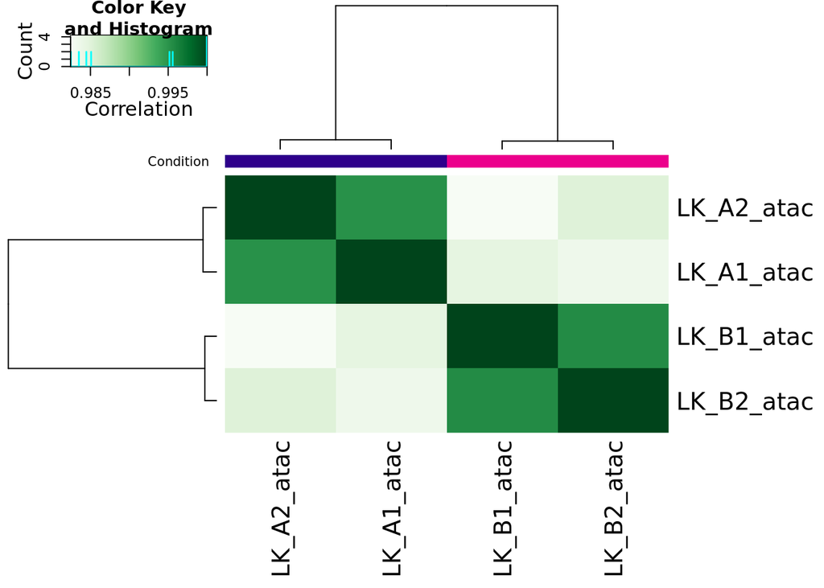

Fig 1: Correlation heatmap, using occupancy (peak caller score) data

Next step is to Calculate a binding matrix with scores based on read counts for every sample (affinity scores), rather than confidence scores for only those peaks called in a specific sample (occupancy scores. Two additional columns were added to above table in this step. The first shows the total number of aligned reads for each sample (the “Full” library sizes). The second is labeled FRiP, which stands for Fraction of Reads in Peaks. This is the proportion of reads for that sample that overlap a peak in the consensus peak set, and can be used to indicate which samples show more enrichment overall.

```
## 4 Samples, 5581 sites in matrix:
##           ID Factor Condition   Reads FRiP
## 1 LK_A1_atac   atac         1 4547370 0.20
## 2 LK_A2_atac   atac         1 5115440 0.19
## 3 LK_B1_atac   atac         2 6728834 0.23
## 4 LK_B2_atac   atac         2 6777428 0.24
```

For each sample, multiplying the value in theReadscolumn by the correspondingFRiPvaluewill yield the number of reads that overlap a consensus peak

| LibReads | FRiP | PeakReads |
| --- | --- | --- |
| 4547370 | 0.20 | 909474 |
| 5115440 | 0.19 | 971934 |
| 6728834 | 0.23 | 1547632 |
| 6777428 | 0.24 | 1626583 |

[output not shown]

4 rows

New correlation heatmap based on the count scores

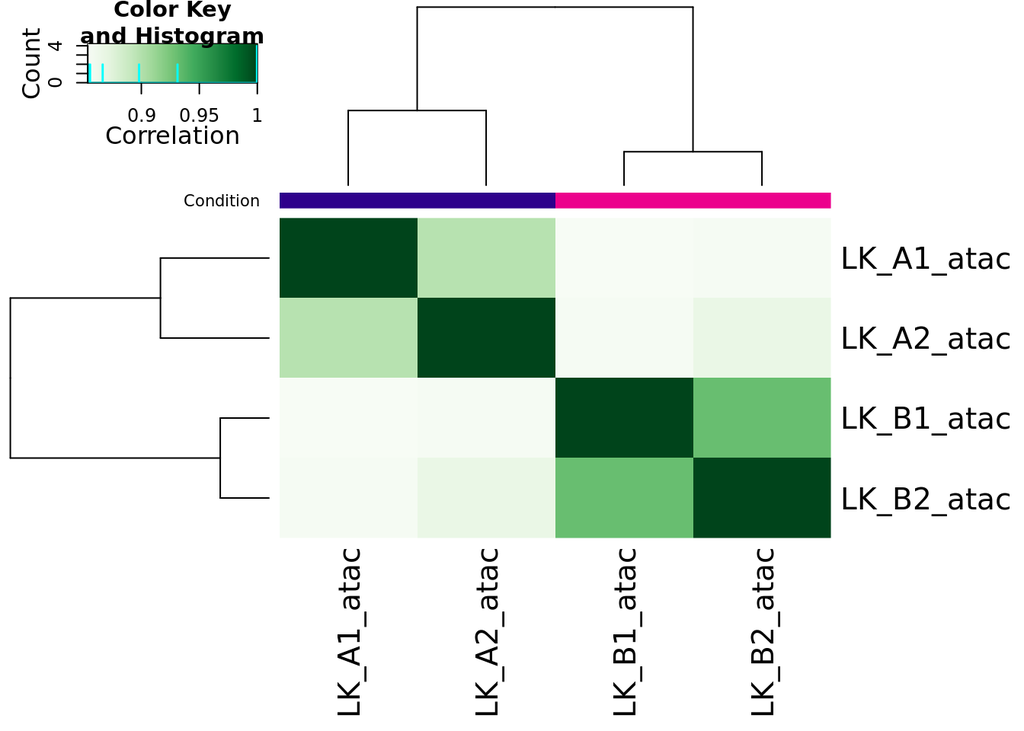

Fig 2.1: Correlation heatmap, using affinity (read count) data

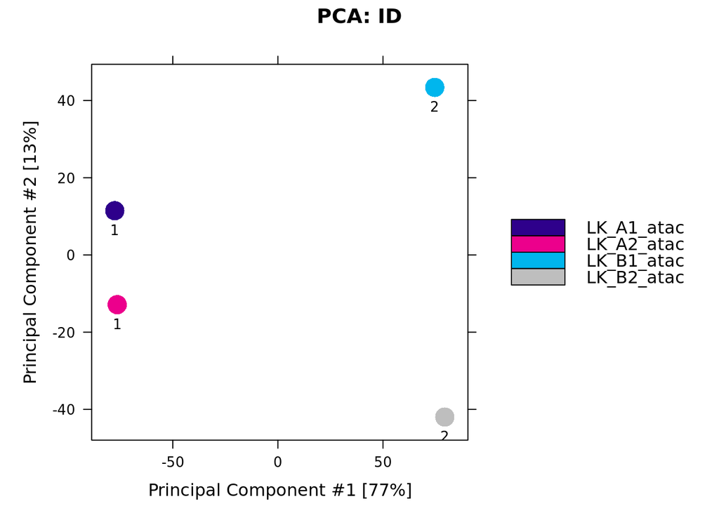

Fig 2.2: PCA plot using affinity (read count) data for all sites

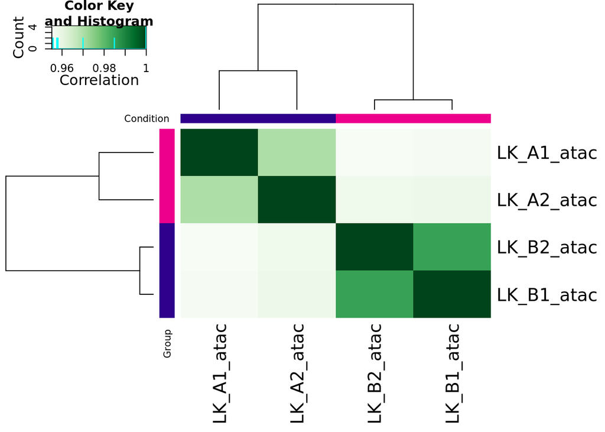

Fig 3.1: Correlation heatmap, using only significantly differentially bound sites

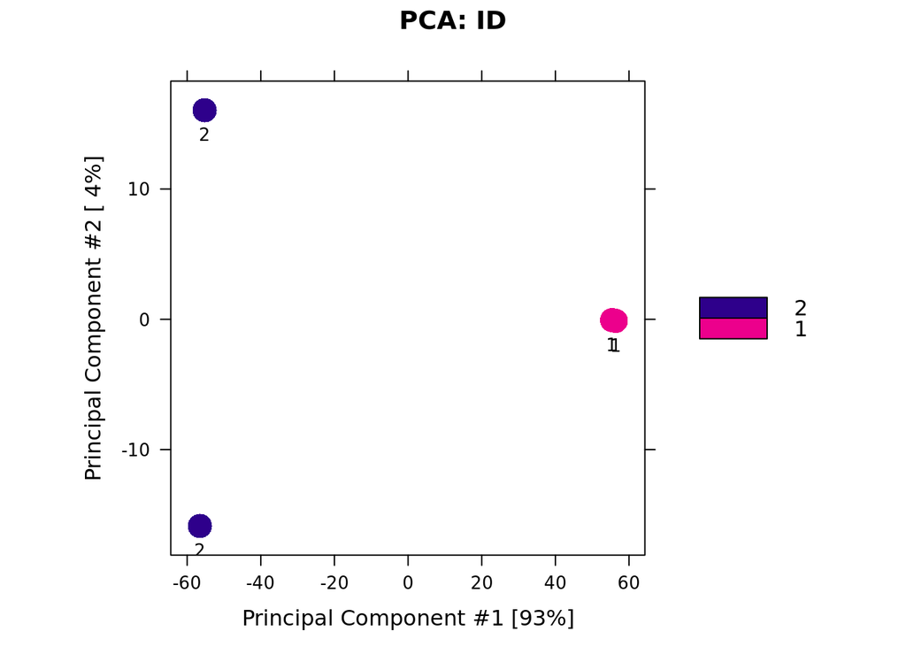

Fig 3.2: PCA plot using affinity data for only differentially bound sites

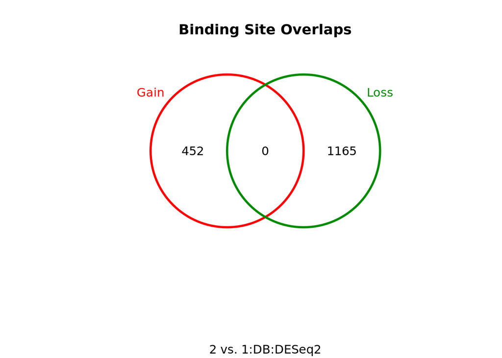

Fig 4: Ven diagram of Gain vs Loss differentially bound sites

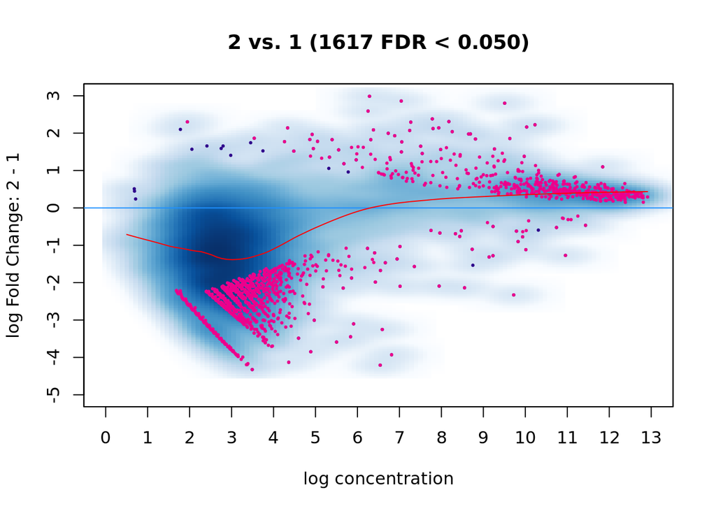

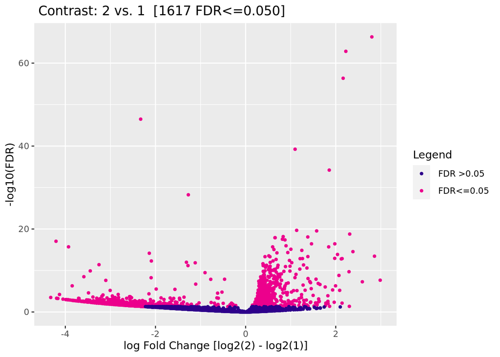

Below table displays first 6 rows of the differential analysis results using DBA_DESEQ2

|  | seqnames | start | end | width | strand | Conc | Conc_2 | Conc_1 | Fold | p.value | FDR |
| --- | --- | --- | --- | --- | --- | --- | --- | --- | --- | --- | --- |
| 3115 | chr19 | 33332210 | 33332610 | 401 | * | 9.507697 | 10.316706 | 7.496067 | 2.801036 | 8.508903e-71 | 4.748819e-67 |
| 280 | chr19 | 8640229 | 8640629 | 401 | * | 10.229897 | 10.951458 | 8.719586 | 2.223765 | 5.129544e-67 | 1.431399e-63 |
| 54 | chr19 | 296462 | 296862 | 401 | * | 10.032127 | 10.743355 | 8.569387 | 2.164132 | 2.381940e-60 | 4.431202e-57 |
| 201 | chr19 | 6590766 | 6591166 | 401 | * | 9.722901 | 8.119049 | 10.463614 | -2.328558 | 2.312721e-50 | 3.226825e-47 |
| 3109 | chr19 | 33302426 | 33302826 | 401 | * | 11.843420 | 12.291582 | 11.189838 | 1.097924 | 5.157188e-43 | 5.756453e-40 |
| 716 | chr19 | 14661429 | 14661829 | 401 | * | 9.630914 | 10.281728 | 8.413142 | 1.856010 | 6.666121e-38 | 6.200603e-35 |

[output not shown]

6 rows | 1-10 of 12 columns

```
## [1] "complted differential binding analysis"
```